# genlasso

非線形な関係を捉えることができているため、 GLMと比べて予測精度が大幅に向上していることがわかります。

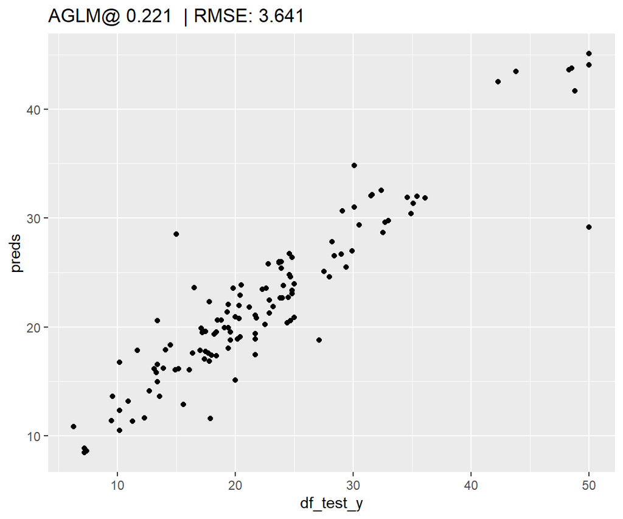

```r
#予測精度の確認
preds <- predict(
  object = model_cv.aglm,
  newx = df_test_X,
  s = lambda_aglm_best
) |> c() # 行列形式の出力をベクトルに変換
.rmse <- round(yardstick::rmse_vec(df_test_y, preds), 3)
ggplot(mapping = aes(x = df_test_y, y = preds)) +
  geom_point() +
  ggtitle(paste("AGLM@", lambda_aglm_best, " | RMSE:", .rmse))
```

予測関数は説明変数の1変数関数の和で表現されているので、 説明変数ごとに予想関数を分けてプロットすることで 予測関数の形を把握することも可能です。

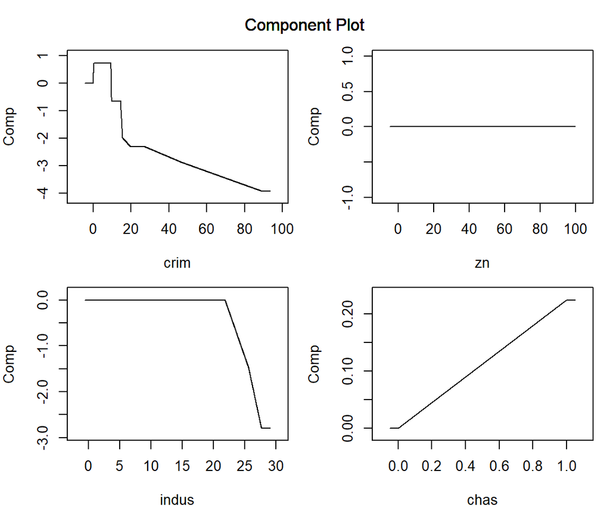

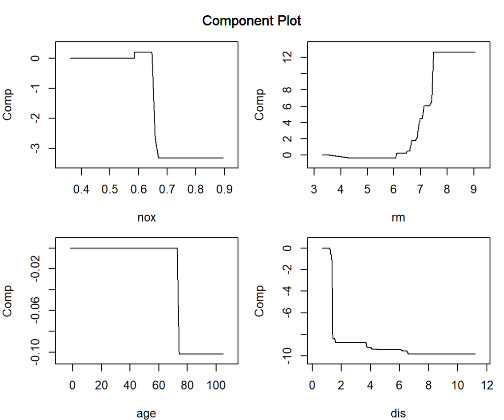

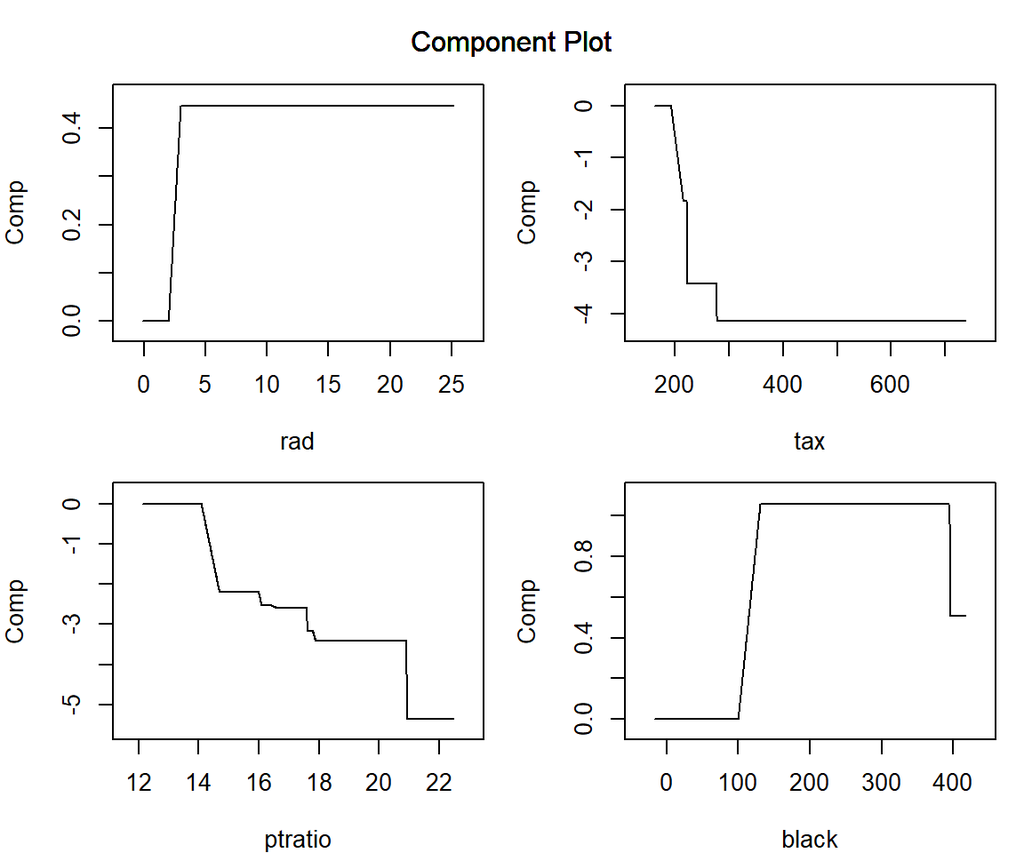

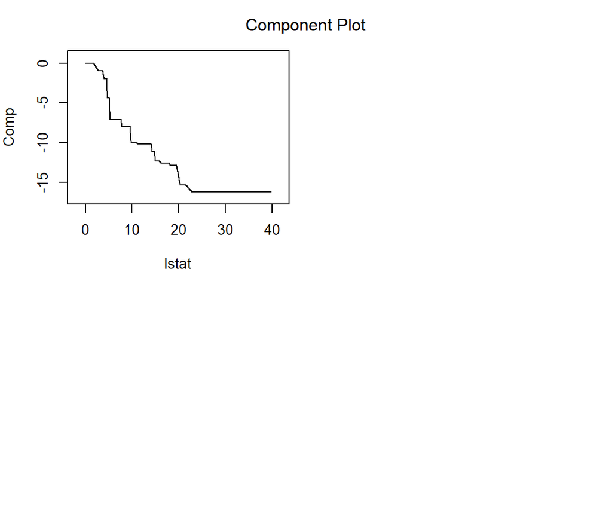

```r
par(mar = c(4, 4, 1, 1)) # プロット領域中の余白を調整
plot(model_cv.aglm, verbose = FALSE, vars = NULL,
     s = lambda_aglm_best, ask = FALSE)
```

このように AGLM は予測精度と解釈可能性をある程度両立したモデルであり、 さらに glmnet パッケージの利点を多く継承していることから、 genlasso パッケージよりもこちらを利用したほうがよいケースも多いでしょう。

## 参考文献

Ryan J. Tibshirani, and Jonathan Taylor. 2011. “The Solution Path of the Generalized Lasso.” Preprint. https://www.stat.cmu.edu/~ryantibs/papers/genlasso.pdf.

Suguru Fujita, Toyoto Tanaka, Kenji Kondo, and Hirokazu Iwasawa. 2020. “A Hybrid Modeling Method of GLM and Data Science Techniques.” Preprint. https://www.institutdesactuaires.com/global/gene/link.php?doc_id=16273&fg=1.

Taylor B. Arnold, and Ryan J. Tibshirani. 2016. “Efficient Implementations of the Generalized Lasso Dual Path Algorithm.” Preprint. https://www.stat.cmu.edu/~ryantibs/papers/fastgl.pdf.

Taylor B. Arnold, and Ryan Tibshirani. 2019. “Introduction to the Genlasso Package.” Preprint. https://ryantibs.r-universe.dev/genlasso/doc/article.pdf.

岩沢 宏和, and 平松 雄司. 2019. *入門 Rによる予測モデリング*. 東京図書.

藤田 卓, 田中 豊人, and 岩沢 宏和. 2019. “アクチュアリー実務のためのデータサイエンスの技術を用いたglmの拡張.” Preprint. https://www.jarip.org/publication/risk_and_insurance/pdf/RI_v15_045.pdf.

## Footnotes

[^1]: ここでは切片項を省略して表示しています。
[^2]: 以下断りが無ければ、Section 3.1 で標準化したものです。
[^3]: 本稿ではこれを踏まえて、定数×観測数 の形で λ を指定している箇所が存在します。
[^4]: 直上の例での標準化やビンの設定などは genlasso パッケージの結果を再現するために設定したものです。 以下の例では再現の必要が無いため、aglm パッケージのデフォルト値に戻しています。